# Multi-Class Tabular Model for Avila Bible Identification Using Python and TensorFlow Decision Forests

### May 17, 2022

SUMMARY: The project aims to construct a predictive model using various machine learning algorithms and document the end-to-end steps using a template. The Avila Bible Identification dataset is a multi-class modeling situation where we attempt to predict one of several (more than two) possible outcomes.

INTRODUCTION: The Avila dataset includes 800 images extracted from the "Avila Bible," a giant Latin copy of the whole Bible produced during the XII century between Italy and Spain. The paleographic analysis of the manuscript has identified the presence of 12 transcribers; however, each transcriber did not transcribe the same number of pages. The prediction task is to associate each pattern to one of the 12 transcribers labeled as A, B, C, D, E, F, G, H, I, W, X, and Y. The research team normalized the data using the Z-normalization method and divided the dataset into two portions, training and test. The training set contains 10,430 samples, while the test set contains 10,437 samples.

ANALYSIS: The performance of the preliminary Gradient Boosted Trees model achieved an accuracy benchmark of 99.99% on the training dataset. When we applied the finalized model to the test dataset, the model achieved an accuracy score of 99.87%.

CONCLUSION: In this iteration, the TensorFlow Decision Forests model appeared to be a suitable algorithm for modeling this dataset.

Dataset Used: Avila Bible Dataset

Dataset ML Model: Multi-Class classification with numerical features

Dataset Reference: https://archive-beta.ics.uci.edu/ml/datasets/avila

One source of potential performance benchmarks: https://www.sciencedirect.com/science/article/abs/pii/S0952197618300721

## Task 1 - Prepare Environment

```python
# Install TensorFlow Decision Forests.
!pip3 install tensorflow_decision_forests --upgrade
```

```python
# Retrieve the CPU information
ncpu = !nproc
print("The number of available CPUs is:", ncpu[0])
```

```
The number of available CPUs is: 2
```

### 1.a) Load libraries and modules

```python
# Set the random seed number for reproducible results
RNG_SEED = 888
```

```python
import random
random.seed(RNG_SEED)
import numpy as np
np.random.seed(RNG_SEED)
import pandas as pd
import seaborn as sns
import matplotlib
import matplotlib.pyplot as plt
import os
import sys
import math
# import boto3
import zipfile
from datetime import datetime
from sklearn import preprocessing
from sklearn.model_selection import train_test_split
from sklearn.model_selection import RepeatedKFold
from sklearn.metrics import classification_report
from sklearn.metrics import confusion_matrix
from sklearn.metrics import accuracy_score
from sklearn.pipeline import Pipeline
from sklearn import compose
from sklearn import impute
from sklearn import metrics
import tensorflow as tf
tf.random.set_seed(RNG_SEED)
# from tensorflow import keras
import tensorflow_decision_forests as tfdf
```

```
WARNING:root:TF Parameter Server distributed training not available (this is expected for the pre-build release).
```

### 1.b) Set up the controlling parameters and functions

```python
# Begin the timer for the script processing
start_time_script = datetime.now()

# Set up the number of CPU cores available for multi-thread processing
N_JOBS = 1

# Set up the flag to stop sending progress emails (setting to True will send status emails!)
NOTIFY_STATUS = False

# Set the percentage sizes for splitting the dataset
TEST_SET_RATIO = 0.1
VAL_SET_RATIO = 0.1

# Set the name for the class/label column
ORIGINAL_LABEL = 'Class'
CLASS_COLUMN = 'target'

# Set the number of folds for cross validation
N_FOLDS = 5
N_ITERATIONS = 1

# Set various default modeling parameters
DEFAULT_METRICS = ["accuracy", tf.keras.metrics.SparseCategoricalCrossentropy()]

# Define the directory locations and file names
TRAIN_DATASET = 'avila-tr.txt'
TEST_DATASET = 'avila-ts.txt'

# Print out the TensorFlow version for confirmation
print('TensorFlow version:', tf.__version__)

# Check the version of TensorFlow Decision Forests
print("Found TensorFlow Decision Forests v" + tfdf.__version__)
```

```
TensorFlow version: 2.8.0
Found TensorFlow Decision Forests v0.2.4
```

```python
# Set up the email notification function
def status_notify(msg_text):
    access_key = os.environ.get('SNS_ACCESS_KEY')
    secret_key = os.environ.get('SNS_SECRET_KEY')
    aws_region = os.environ.get('SNS_AWS_REGION')
    topic_arn = os.environ.get('SNS_TOPIC_ARN')
    if (access_key is None) or (secret_key is None) or (aws_region is None):
        sys.exit("Incomplete notification setup info. Script Processing Aborted!!!")
    sns = boto3.client('sns', aws_access_key_id=access_key, aws_secret_access_key=secret_key, region_name=aws_region)
    response = sns.publish(TopicArn=topic_arn, Message=msg_text)
    if response['ResponseMetadata']['HTTPStatusCode'] != 200 :
        print('Status notification not OK with HTTP status code:', response['ResponseMetadata']['HTTPStatusCode'])
```

```python
if NOTIFY_STATUS: status_notify("Task 1 - Prepare Environment has begun! " + datetime.now().strftime('%a %B %d, %Y %I:%M:%S %p'))
```

### 1.c) Load dataset

```python
if not os.path.exists(TRAIN_DATASET):
    !wget https://dainesanalytics.com/datasets/ucirvine-avila-bible-identification/avila-tr.txt
```

```python
colNames = ['F1','F2','F3','F4','F5','F6','F7','F8','F9','F10','Class']
df_dataset_import = pd.read_csv(TRAIN_DATASET, names=colNames, sep=',', header=None, index_col=False)

# Take a peek at the dataframe after import
print(df_dataset_import.head())
```

```
         F1        F2        F3        F4        F5        F6        F7  \
0  0.266074 -0.165620  0.320980  0.483299  0.172340  0.273364  0.371178
1  0.130292  0.870736 -3.210528  0.062493  0.261718  1.436060  1.465940
2 -0.116585  0.069915  0.068476 -0.783147  0.261718  0.439463 -0.081827
3  0.031541  0.297600 -3.210528 -0.583590 -0.721442 -0.307984  0.710932
4  0.229043  0.807926 -0.052442  0.082634  0.261718  0.148790  0.635431

         F8        F9       F10 Class
0  0.929823  0.251173  0.159345     A
1  0.636203  0.282354  0.515587     A
2 -0.888236 -0.123005  0.582939     A
3  1.051693  0.594169 -0.533994     A
4  0.051062  0.032902 -0.086652     F
```

```python
df_dataset_import.info(verbose=True)
```

```
<class 'pandas.core.frame.DataFrame'>
RangeIndex: 10430 entries, 0 to 10429
Data columns (total 11 columns):
 #   Column  Non-Null Count  Dtype
---  ------  --------------  -----
 0   F1      10430 non-null  float64
 1   F2      10430 non-null  float64
 2   F3      10430 non-null  float64
 3   F4      10430 non-null  float64
 4   F5      10430 non-null  float64
 5   F6      10430 non-null  float64
 6   F7      10430 non-null  float64
 7   F8      10430 non-null  float64
 8   F9      10430 non-null  float64
 9   F10     10430 non-null  float64
 10  Class   10430 non-null  object
dtypes: float64(10), object(1)
memory usage: 896.5+ KB
```

```python
print(df_dataset_import.describe())
```

```
                 F1            F2            F3            F4            F5  \
count  10430.000000  10430.000000  10430.000000  10430.000000  10430.000000
mean       0.000852      0.033611     -0.000525     -0.002387      0.006370
std        0.991431      3.920868      1.120202      1.008527      0.992053
min       -3.498799     -2.426761     -3.210528     -5.440122     -4.922215
25%       -0.128929     -0.259834      0.064919     -0.528002      0.172340
50%        0.043885     -0.055704      0.217845      0.095763      0.261718
75%        0.204355      0.203385      0.352988      0.658210      0.261718
max       11.819916    386.000000     50.000000      3.987152      1.066121

                 F6            F7            F8            F9           F10
count  10430.000000  10430.000000  10430.000000  10430.000000  10430.000000
mean       0.013973      0.005605      0.010323      0.012914      0.000818
std        1.126245      1.313754      1.003507      1.087665      1.007094
min       -7.450257    -11.935457     -4.247781     -5.486218     -6.719324
25%       -0.598658     -0.044076     -0.541991     -0.372457     -0.516097
50%       -0.058835      0.220177      0.111803      0.064084     -0.034513
75%        0.564038      0.446679      0.654944      0.500624      0.530855
max       53.000000     83.000000     13.173081     44.000000      4.671232
```

```python
print(df_dataset_import.isnull().sum())
print('Total number of NaN in the dataframe: ', df_dataset_import.isnull().sum().sum())
```

```
F1       0
F2       0
F3       0
F4       0
F5       0
F6       0
F7       0
F8       0
F9       0
F10      0
Class    0
dtype: int64
Total number of NaN in the dataframe:  0
```

```python
# Get grouping size for the target variable
print(df_dataset_import.groupby(ORIGINAL_LABEL).size())
```

```
Class
A    4286
B       5
C     103
D     352
E    1095
F    1961
G     446
H     519
I     831
W      44
X     522
Y     266
dtype: int64
```

### 1.d) Data Cleaning

```python
# Standardize the class column to the name of targetVar if required
df_dataset_import = df_dataset_import.rename(columns={ORIGINAL_LABEL: CLASS_COLUMN})

# Transform the string classes into integers
label_encoder = preprocessing.LabelEncoder()
df_dataset_import[CLASS_COLUMN] = label_encoder.fit_transform(df_dataset_import[CLASS_COLUMN])

# Take a peek at the dataframe after cleaning
print(df_dataset_import.head())
```

```
         F1        F2        F3        F4        F5        F6        F7  \
0  0.266074 -0.165620  0.320980  0.483299  0.172340  0.273364  0.371178
1  0.130292  0.870736 -3.210528  0.062493  0.261718  1.436060  1.465940
2 -0.116585  0.069915  0.068476 -0.783147  0.261718  0.439463 -0.081827
3  0.031541  0.297600 -3.210528 -0.583590 -0.721442 -0.307984  0.710932
4  0.229043  0.807926 -0.052442  0.082634  0.261718  0.148790  0.635431

         F8        F9       F10  target
0  0.929823  0.251173  0.159345       0
1  0.636203  0.282354  0.515587       0
2 -0.888236 -0.123005  0.582939       0
3  1.051693  0.594169 -0.533994       0
4  0.051062  0.032902 -0.086652       5
```

```python
df_dataset_import.info(verbose=True)
```

```
<class 'pandas.core.frame.DataFrame'>
RangeIndex: 10430 entries, 0 to 10429
Data columns (total 11 columns):
 #   Column  Non-Null Count  Dtype
---  ------  --------------  -----
 0   F1      10430 non-null  float64
 1   F2      10430 non-null  float64
 2   F3      10430 non-null  float64
 3   F4      10430 non-null  float64
 4   F5      10430 non-null  float64
 5   F6      10430 non-null  float64
 6   F7      10430 non-null  float64
 7   F8      10430 non-null  float64
 8   F9      10430 non-null  float64
 9   F10     10430 non-null  float64
 10  target  10430 non-null  int64
dtypes: float64(10), int64(1)
memory usage: 896.5 KB
```

```python
print(df_dataset_import.describe())
```

```
                 F1            F2            F3            F4            F5  \
count  10430.000000  10430.000000  10430.000000  10430.000000  10430.000000
mean       0.000852      0.033611     -0.000525     -0.002387      0.006370
std        0.991431      3.920868      1.120202      1.008527      0.992053
min       -3.498799     -2.426761     -3.210528     -5.440122     -4.922215
25%       -0.128929     -0.259834      0.064919     -0.528002      0.172340
50%        0.043885     -0.055704      0.217845      0.095763      0.261718
75%        0.204355      0.203385      0.352988      0.658210      0.261718
max       11.819916    386.000000     50.000000      3.987152      1.066121

                 F6            F7            F8            F9           F10  \
count  10430.000000  10430.000000  10430.000000  10430.000000  10430.000000
mean       0.013973      0.005605      0.010323      0.012914      0.000818
std        1.126245      1.313754      1.003507      1.087665      1.007094
min       -7.450257    -11.935457     -4.247781     -5.486218     -6.719324
25%       -0.598658     -0.044076     -0.541991     -0.372457     -0.516097
50%       -0.058835      0.220177      0.111803      0.064084     -0.034513
75%        0.564038      0.446679      0.654944      0.500624      0.530855
max       53.000000     83.000000     13.173081     44.000000      4.671232

             target
count  10430.000000
mean       3.542761
std        3.418046
min        0.000000
25%        0.000000
50%        4.000000
75%        6.000000
max       11.000000
```

```python
print(df_dataset_import.isnull().sum())
print('Total number of NaN in the dataframe: ', df_dataset_import.isnull().sum().sum())
```

```
F1        0
F2        0
F3        0
F4        0
F5        0
F6        0
F7        0
F8        0
F9        0
F10       0
target    0
dtype: int64
Total number of NaN in the dataframe:  0
```

```python
# Get grouping size for the target variable
print(df_dataset_import.groupby(CLASS_COLUMN).size())
```

```
target
0     4286
1        5
2      103
3      352
4     1095
5     1961
6      446
7      519
8      831
9       44
10     522
11     266
dtype: int64
```

### 1.e) Splitting Data into Sets

```python
# Use variable total_column_count to hold the number of columns in the dataframe
total_column_count = len(df_dataset_import.columns)

# Set up variable total_feature_count for the total number of attribute columns
total_feature_count = total_column_count-1

# We create attribute-only and target-only datasets
df_target_train = df_dataset_import[CLASS_COLUMN]
df_features_train = df_dataset_import.drop([CLASS_COLUMN], axis=1)

print("df_dataset_import.shape: {} df_features_train.shape: {} df_target_train.shape: {}".format(df_dataset_import.shape, df_features_train.shape, df_target_train.shape))
```

```
df_dataset_import.shape: (10430, 11) df_features_train.shape: (10430, 10) df_target_train.shape: (10430,)
```

### 1.f) Set up the parameters for data visualization

```python
# Set up the number of row and columns for visualization display. display_rows * display_columns should be >= total_feature_count
display_columns = 4
if total_feature_count % display_columns == 0 :
    display_rows = total_feature_count // display_columns
else :
    display_rows = (total_feature_count // display_columns) + 1

# Set figure width to display the data visualization plots
fig_size = plt.rcParams["figure.figsize"]
fig_size[0] = display_columns * 4
fig_size[1] = display_rows * 4
plt.rcParams["figure.figsize"] = fig_size
```

```python
if NOTIFY_STATUS: status_notify("Task 1 - Prepare Environment completed! "+datetime.now().strftime('%a %B %d, %Y %I:%M:%S %p'))
```

## Task 2 - Summarize and Visualize Data

```python
if NOTIFY_STATUS: status_notify("Task 2 - Summarize and Visualize Data has begun! "+datetime.now().strftime('%a %B %d, %Y %I:%M:%S %p'))
```

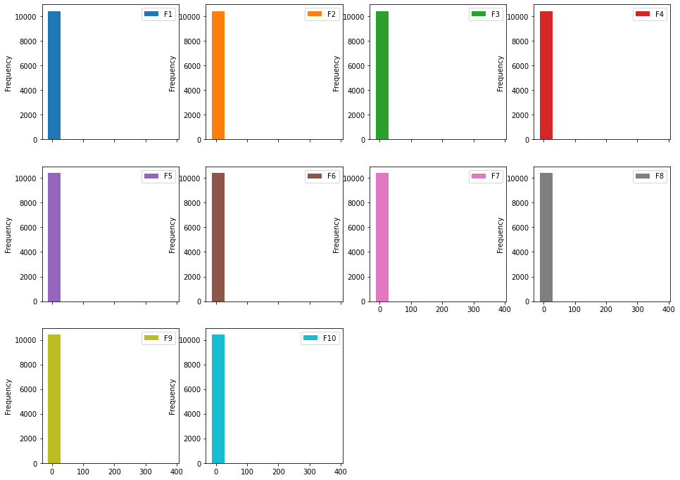

```python
# Histograms for each attribute
df_features_train.plot(kind='hist', subplots=True, layout=(display_rows, display_columns))
plt.show()
```

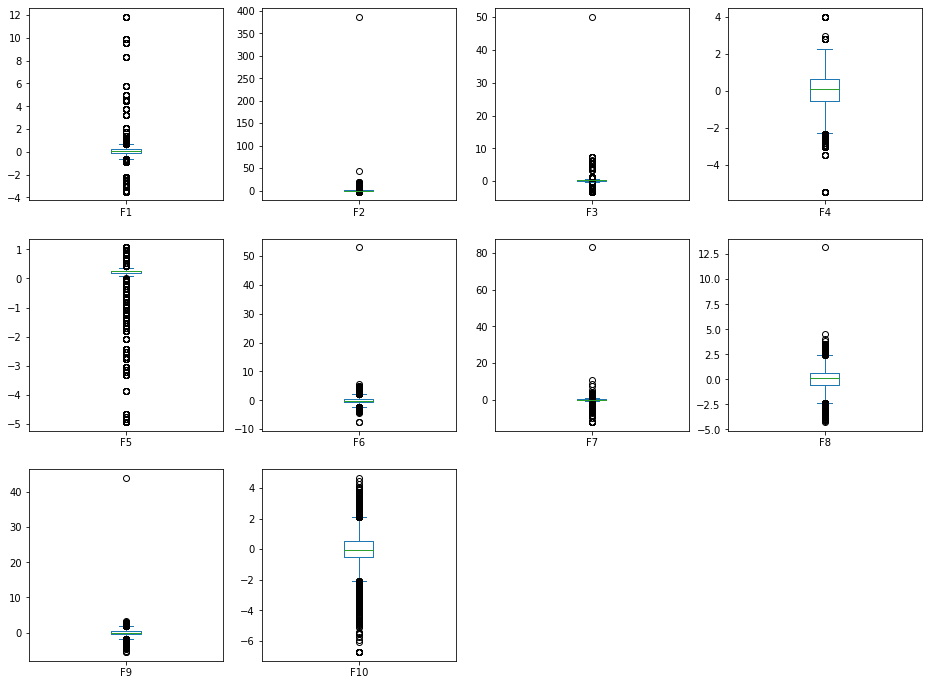

```python
# Box and Whisker plot for each attribute
df_features_train.plot(kind='box', subplots=True, layout=(display_rows, display_columns))
plt.show()
```

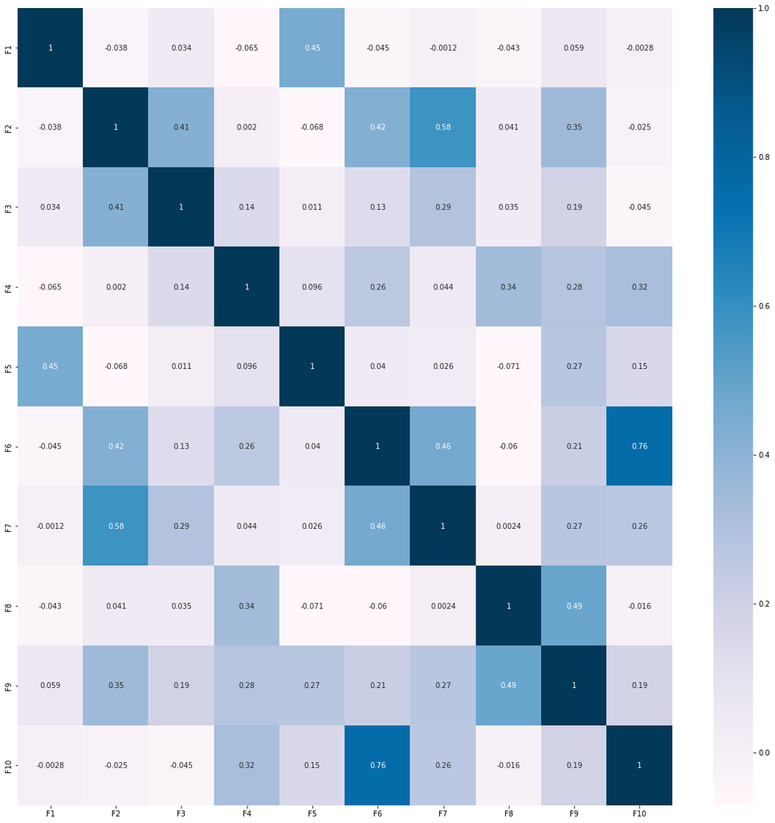

```python
# Correlation matrix
fig = plt.figure(figsize=(20, 20))
correlations = df_features_train.corr(method='pearson')
sns.heatmap(correlations, annot=True, cmap=plt.cm.PuBu)
plt.show()
```

```python
if NOTIFY_STATUS: status_notify("Task 2 - Summarize and Visualize Data completed! "+datetime.now().strftime('%a %B %d, %Y %I:%M:%S %p'))
```

## Task 3 - Train and Evaluate Models

```python
if NOTIFY_STATUS: status_notify("Task 3 - Train and Evaluate Models has begun! "+datetime.now().strftime('%a %B %d, %Y %I:%M:%S %p'))
```

### 3.a) Splitting Data into Training and Validation Sets

```python
# Finalize the training dataset for the modeling activities
tfds_train = tfdf.keras.pd_dataframe_to_tf_dataset(df_dataset_import, label=CLASS_COLUMN, task = tfdf.keras.Task.CLASSIFICATION)
```

### 3.b) Train and Evaluate the Random Forest Model

```python
# Define the baseline model for benchmarking
start_time_module = datetime.now()
tf.keras.utils.set_random_seed(RNG_SEED)
RF_model = tfdf.keras.RandomForestModel(task = tfdf.keras.Task.CLASSIFICATION)
RF_model.compile(metrics=DEFAULT_METRICS)

# "sys_pipes" is optional. It enables the display of the training logs.
# with sys_pipes():
#     RF_model.fit(x=tfds_train)

# Train the model.
RF_model.fit(x=tfds_train)
print ('Model training time:', (datetime.now() - start_time_module), '\n')
```

```
Use /tmp/tmppt8ssj79 as temporary training directory
Starting reading the dataset
Dataset read in 0:00:10.765877
Training model
Model trained in 0:00:20.664568
Compiling model
WARNING:tensorflow:AutoGraph could not transform <function simple_ml_inference_op_with_handle at 0x7f6e25438830> and will run it as-is.
Please report this to the TensorFlow team. When filing the bug, set the verbosity to 10 (on Linux, `export AUTOGRAPH_VERBOSITY=10`) and attach the full output.
Cause: could not get source code
To silence this warning, decorate the function with @tf.autograph.experimental.do_not_convert
```

[output not shown]

```
WARNING: AutoGraph could not transform <function simple_ml_inference_op_with_handle at 0x7f6e25438830> and will run it as-is.
Please report this to the TensorFlow team. When filing the bug, set the verbosity to 10 (on Linux, `export AUTOGRAPH_VERBOSITY=10`) and attach the full output.
Cause: could not get source code
To silence this warning, decorate the function with @tf.autograph.experimental.do_not_convert
Model training time: 0:00:33.787879
```

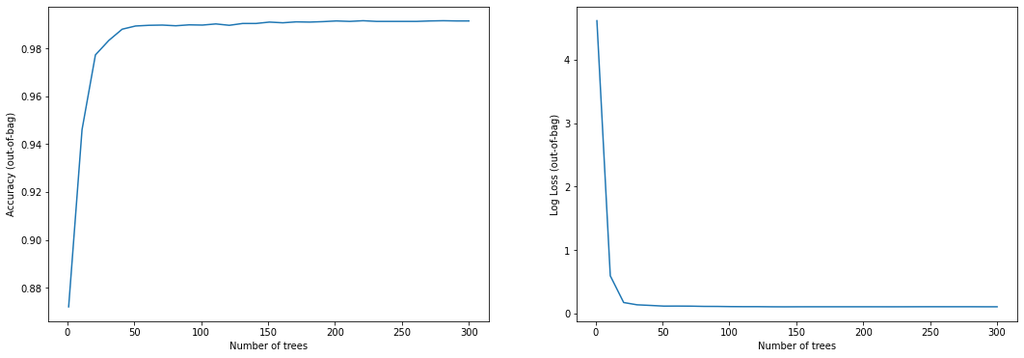

```python
logs = RF_model.make_inspector().training_logs()

plt.figure(figsize=(18, 6))
plt.subplot(1, 2, 1)
plt.plot([log.num_trees for log in logs], [log.evaluation.accuracy for log in logs])
plt.xlabel("Number of trees")
plt.ylabel("Accuracy (out-of-bag)")
plt.subplot(1, 2, 2)
plt.plot([log.num_trees for log in logs], [log.evaluation.loss for log in logs])
plt.xlabel("Number of trees")
plt.ylabel("Log Loss (out-of-bag)")
plt.show()
```

```python
RF_eval = RF_model.evaluate(tfds_train, return_dict=True)
print()

for name, value in RF_eval.items():
    print(f"{name}: {value:.4f}")
```

```
loss: 0.0000
accuracy: 0.9980
sparse_categorical_crossentropy: 0.0627
```

### 3.c) Train and Evaluate the Decision Trees Model

```python
# Define the baseline model for benchmarking
start_time_module = datetime.now()
tf.keras.utils.set_random_seed(RNG_SEED)
CART_model = tfdf.keras.CartModel(task = tfdf.keras.Task.CLASSIFICATION)
CART_model.compile(metrics=DEFAULT_METRICS)

# "sys_pipes" is optional. It enables the display of the training logs.
# with sys_pipes():
#     CART_model.fit(x=tfds_train)

# Train the model.
CART_model.fit(x=tfds_train)
print ('Model training time:', (datetime.now() - start_time_module), '\n')
```

```
Use /tmp/tmpmpf64tw2 as temporary training directory
Starting reading the dataset
Dataset read in 0:00:00.228293
Training model
Model trained in 0:00:00.092174
Compiling model
Model training time: 0:00:00.490023
```

```python
CART_eval = CART_model.evaluate(tfds_train, return_dict=True)
print()

for name, value in CART_eval.items():
    print(f"{name}: {value:.4f}")
```

```
loss: 0.0000
accuracy: 0.9279
sparse_categorical_crossentropy: 0.1354
```

### 3.d) Train and Evaluate the Gradient Boosted Trees Model

```python
# Define the baseline model for benchmarking
start_time_module = datetime.now()
tf.keras.utils.set_random_seed(RNG_SEED)
GBT_model = tfdf.keras.GradientBoostedTreesModel(task = tfdf.keras.Task.CLASSIFICATION)
GBT_model.compile(metrics=DEFAULT_METRICS)

# "sys_pipes" is optional. It enables the display of the training logs.
# with sys_pipes():
#     GBT_model.fit(x=tfds_train)

# Train the model.
GBT_model.fit(x=tfds_train)
print ('Model training time:', (datetime.now() - start_time_module), '\n')
```

```
Use /tmp/tmp2alho5wm as temporary training directory
Starting reading the dataset
Dataset read in 0:00:00.227744
Training model
Model trained in 0:01:12.713720
Compiling model
Model training time: 0:01:13.557227
```

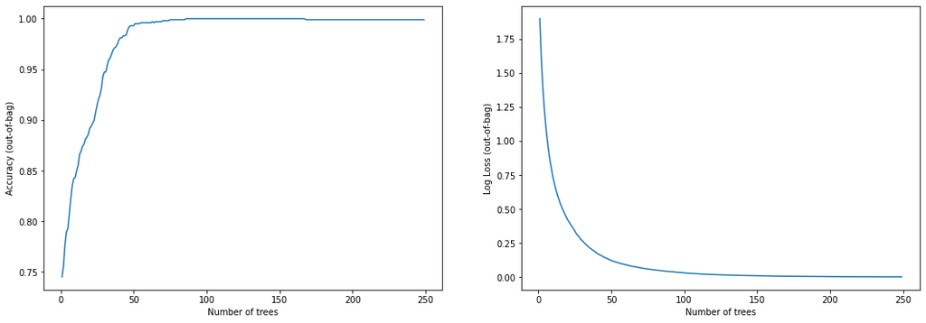

```python
logs = GBT_model.make_inspector().training_logs()

plt.figure(figsize=(18, 6))
plt.subplot(1, 2, 1)
plt.plot([log.num_trees for log in logs], [log.evaluation.accuracy for log in logs])
plt.xlabel("Number of trees")
plt.ylabel("Accuracy (out-of-bag)")
plt.subplot(1, 2, 2)
plt.plot([log.num_trees for log in logs], [log.evaluation.loss for log in logs])
plt.xlabel("Number of trees")
plt.ylabel("Log Loss (out-of-bag)")
plt.show()
```

```python
GBT_eval = GBT_model.evaluate(tfds_train, return_dict=True)
print()

for name, value in GBT_eval.items():
    print(f"{name}: {value:.4f}")
```

```
loss: 0.0000
accuracy: 0.9999
sparse_categorical_crossentropy: 0.0905
```

```python
if NOTIFY_STATUS: status_notify("Task 4 - Train and Evaluate Models completed! "+datetime.now().strftime('%a %B %d, %Y %I:%M:%S %p'))
```

## Task 4 - Fine-tune and Improve Models

```python
if NOTIFY_STATUS: status_notify("Task 4 - Fine-tune and Improve Models has begun! "+datetime.now().strftime('%a %B %d, %Y %I:%M:%S %p'))
```

```python
# Not applicable for this iteration of modeling
```

```python
if NOTIFY_STATUS: status_notify("Task 4 - Fine-tune and Improve Models completed! "+datetime.now().strftime('%a %B %d, %Y %I:%M:%S %p'))
```

## Task 5 - Finalize Model and Present Analysis

```python
if NOTIFY_STATUS: status_notify("Task 5 - Finalize Model and Present Analysis has begun! "+datetime.now().strftime('%a %B %d, %Y %I:%M:%S %p'))
```

### 5.a) Train the Final Model

```python
# Define the baseline model for benchmarking
start_time_module = datetime.now()
tf.keras.utils.set_random_seed(RNG_SEED)
# final_model = tfdf.keras.RandomForestModel(task = tfdf.keras.Task.CLASSIFICATION)
# final_model = tfdf.keras.CartModel(task = tfdf.keras.Task.CLASSIFICATION)
final_model = tfdf.keras.GradientBoostedTreesModel(task = tfdf.keras.Task.CLASSIFICATION)

# Optionally, add evaluation metrics.
final_model.compile(metrics=DEFAULT_METRICS)

# "sys_pipes" is optional. It enables the display of the training logs.
# with sys_pipes():
#     final_model.fit(x=tfds_train)

# Train the model.
final_model.fit(x=tfds_train)
print ('Model training time:', (datetime.now() - start_time_module), '\n')
```

```
Use /tmp/tmps8gctd32 as temporary training directory
Starting reading the dataset
Dataset read in 0:00:00.245618
Training model
Model trained in 0:01:13.364980
Compiling model
Model training time: 0:01:14.207912
```

```python
final_model.summary()
```

```
Model: "gradient_boosted_trees_model_1"
_________________________________________________________________
 Layer (type)                Output Shape              Param #
=================================================================
=================================================================
Total params: 1
Trainable params: 0
Non-trainable params: 1
_________________________________________________________________
Type: "GRADIENT_BOOSTED_TREES"
Task: CLASSIFICATION
Label: "__LABEL"

Input Features (10):
	F1
	F10
	F2
	F3
	F4
	F5
	F6
	F7
	F8
	F9

No weights

Variable Importance: MEAN_MIN_DEPTH:
    1. "__LABEL"  4.682801 ################
    2.     "F10"  4.489483 ##############
    3.      "F6"  4.453804 ##############
    4.      "F7"  4.404905 #############
    5.      "F8"  4.331172 #############
    6.      "F9"  3.886214 #########
    7.      "F5"  3.592903 #######
    8.      "F4"  3.284786 #####
    9.      "F3"  2.978723 ###
   10.      "F2"  2.608491
   11.      "F1"  2.569863

```

[output cut: 174 more lines]

```
	2390 : F6 [NUMERICAL]
	2175 : F7 [NUMERICAL]

Condition type in nodes:
	65227 : HigherCondition
Condition type in nodes with depth <= 0:
	2952 : HigherCondition
Condition type in nodes with depth <= 1:
	8334 : HigherCondition
Condition type in nodes with depth <= 2:
	17876 : HigherCondition
Condition type in nodes with depth <= 3:
	35280 : HigherCondition
Condition type in nodes with depth <= 5:
	65227 : HigherCondition
```

### 5.b) Load Test Dataset and Make Predictions

```python
if not os.path.exists(TEST_DATASET):
    !wget https://dainesanalytics.com/datasets/ucirvine-avila-bible-identification/avila-ts.txt
```

```python
df_dataset_test = pd.read_csv(TEST_DATASET, names=colNames, sep=',', header=None, index_col=False)

# Take a peek at the dataframe after import
print(df_dataset_test.head())
```

```
         F1        F2        F3        F4        F5        F6        F7  \
0 -3.498799  0.250492  0.232070  1.224178 -4.922215  1.145386  0.182426
1  0.204355 -0.354049  0.320980  0.410166 -0.989576 -2.218127  0.220177
2  0.759828 -1.304042 -0.023991 -0.973663 -0.006417 -0.349509 -0.421580
3 -0.005490  0.360409  0.281860 -0.213479 -1.168333 -1.013906 -0.346080
4  0.080916  0.101320  0.104040  0.140490  0.261718  0.480988  0.710932

         F8        F9       F10 Class
0 -0.165983 -0.123005  1.087144     W
1  0.181844  2.090879 -2.009758     A
2 -0.450127  0.469443  0.060952     I
3  1.176165  0.968347 -0.627999     E
4 -0.253430 -0.497183  0.155681     A
```

```python
# Standardize the class column to the name of targetVar if required
df_dataset_test = df_dataset_test.rename(columns={ORIGINAL_LABEL: CLASS_COLUMN})

# Transform the string classes into integers
df_dataset_test[CLASS_COLUMN] = label_encoder.transform(df_dataset_test[CLASS_COLUMN])

# Take a peek at the dataframe after cleaning
print(df_dataset_test.head())
```

```
         F1        F2        F3        F4        F5        F6        F7  \
0 -3.498799  0.250492  0.232070  1.224178 -4.922215  1.145386  0.182426
1  0.204355 -0.354049  0.320980  0.410166 -0.989576 -2.218127  0.220177
2  0.759828 -1.304042 -0.023991 -0.973663 -0.006417 -0.349509 -0.421580
3 -0.005490  0.360409  0.281860 -0.213479 -1.168333 -1.013906 -0.346080
4  0.080916  0.101320  0.104040  0.140490  0.261718  0.480988  0.710932

         F8        F9       F10  target
0 -0.165983 -0.123005  1.087144       9
1  0.181844  2.090879 -2.009758       0
2 -0.450127  0.469443  0.060952       8
3  1.176165  0.968347 -0.627999       4
4 -0.253430 -0.497183  0.155681       0
```

```python
# Extract the class column from the test dataset for later comparison
df_target_test = df_dataset_test[CLASS_COLUMN]
array_target_test = df_target_test.ravel()
print("Shape of df_target_test: {}".format(array_target_test.shape))
```

```
Shape of df_target_test: (10437,)
```

```python
# Finalize the test dataset for the prediction activities
tfds_test = tfdf.keras.pd_dataframe_to_tf_dataset(df_dataset_test, label=CLASS_COLUMN, task = tfdf.keras.Task.CLASSIFICATION)
```

```python
# Make batched predictions
# test_predictions = label_encoder.inverse_transform(np.argmax(final_model.predict(tfds_test), axis=-1))
test_predictions = np.argmax(final_model.predict(tfds_test), axis=-1)
print(test_predictions)
```

[output not shown]

[output not shown]

```
[9 0 8 ... 0 5 7]
```

```python
print('Accuracy Score:', accuracy_score(array_target_test, test_predictions),'\n')
print(confusion_matrix(array_target_test, test_predictions),'\n')
print(classification_report(array_target_test, test_predictions))
```

```
Accuracy Score: 0.9987544313500047

[[4286    0    0    0    0    0    0    0    0    0    0    0]
 [   0    5    0    0    0    0    0    0    0    0    0    0]
 [   0    0  103    0    0    0    0    0    0    0    0    0]
 [   0    0    0  353    0    0    0    0    0    0    0    0]
 [   0    0    0    0 1095    0    0    0    0    0    0    0]
 [   0    0    0    0    0 1962    0    0    0    0    0    0]
 [   0    0    0    0    0    0  447    0    0    0    0    0]
 [   0    0    3    0    0    0    0  517    0    0    0    0]
 [   3    0    0    0    0    0    0    0  829    0    0    0]
 [   0    0    0    0    0    0    0    0    0   45    0    0]
 [   3    0    0    0    3    0    0    0    0    0  516    0]
 [   0    0    0    0    0    0    0    0    0    0    1  266]]

              precision    recall  f1-score   support

           0       1.00      1.00      1.00      4286
           1       1.00      1.00      1.00         5
           2       0.97      1.00      0.99       103
           3       1.00      1.00      1.00       353
           4       1.00      1.00      1.00      1095
           5       1.00      1.00      1.00      1962
           6       1.00      1.00      1.00       447
           7       1.00      0.99      1.00       520
           8       1.00      1.00      1.00       832
           9       1.00      1.00      1.00        45
          10       1.00      0.99      0.99       522
          11       1.00      1.00      1.00       267

    accuracy                           1.00     10437
   macro avg       1.00      1.00      1.00     10437
weighted avg       1.00      1.00      1.00     10437
```

```python
if NOTIFY_STATUS: status_notify("Task 5 - Finalize Model and Present Analysis completed! "+datetime.now().strftime('%a %B %d, %Y %I:%M:%S %p'))
```

```python
print ('Total time for the script:',(datetime.now() - start_time_script))
```

```
Total time for the script: 0:03:16.609884
```